# 811257709 FML ASSIGNMENT 2

SIVA SAI MADHUMITHA KOTALA

2023-10-01

```r
knitr::opts_chunk$set(echo = TRUE)
```

# Summary

The goal of the assignment is to forecast, using KNN(k-Nearest Neighbors)Classification, if the loan offer will be accepted by Universal Bank’s customers. The dataset includes customer demographic data as well as other cilent-related details. The dataset is first read, the necessary libraries are installed, and then unnecessary columns are deleted, category categories are turned to dummy variables, and the data is finally normalized. The dataset was then split into two sets, training and validation, each containing 60% and 40% of the total data. Using k-NN with k=1, a new customer was classified as either accepting or rejecting a loan offer. The ideal k value, which strikes a balance between overfitting and underfitting, was discovered by evaluating accuracy on the validation set, with k=3 being the best choice. The confusion matrix was created for the validation data with the best k value. The procedure was then repeated using a different data partitioning scheme (50% training, 30% validation, 20% test) to assess the model’s generalization performance. Then, confusion matrices between the training, validation, and test sets were compared.

# Problem Statement

Universal bank is a young bank growing rapidly in terms of overall customer acquisition. The majority of these customers are liability customers (depositors) with varying sizes of relationship with the bank. The customer base of asset customers (borrowers) is quite small, and the bank is interested in expanding this base rapidly in more loan business. In particular, it wants to explore ways of converting its liability customers to personal loan customers.

A campaign that the bank ran last year for liability customers showed a healthy conversion rate of over 9% success. This has encouraged the retail marketing department to devise smarter campaigns with better target marketing. The goal is to use k-NN to predict whether a new customer will accept a loan offer. This will serve as the basis for the design of a new campaign.

The file UniversalBank.csv contains data on 5000 customers. The data include customer demographic information (age, income, etc.), the customer’s relationship with the bank (mortgage, securities account, etc.), and the customer response to the last personal loan campaign (Personal Loan). Among these 5000 customers, only 480 (= 9.6%) accepted the personal loan that was offered to them in the earlier campaign.

Partition the data into training (60%) and validation (40%) sets.

# Data Import and Cleaning

First,we should install the packages like“class”,“caret”,“e1071” and then we should call the libraries “class”,“caret”,“e1071”

```r
library(class)
library(caret)
library(e1071)
```

# Reading the data.

```r
unibank.info<- read.csv("C:/Users/Lenovo/Desktop/UNIBANK/UniversalBank.csv")
dim(unibank.info)
```

```
## [1] 5000   14
```

```r
head(unibank.info)
```

```
##   ID Age Experience Income ZIP.Code Family CCAvg Education Mortgage
## 1  1  25          1     49    91107      4   1.6         1        0
## 2  2  45         19     34    90089      3   1.5         1        0
## 3  3  39         15     11    94720      1   1.0         1        0
## 4  4  35          9    100    94112      1   2.7         2        0
## 5  5  35          8     45    91330      4   1.0         2        0
## 6  6  37         13     29    92121      4   0.4         2      155
##   Personal.Loan Securities.Account CD.Account Online CreditCard
## 1             0                  1          0      0          0
## 2             0                  1          0      0          0
## 3             0                  0          0      0          0
## 4             0                  0          0      0          0
## 5             0                  0          0      0          1
## 6             0                  0          0      1          0
```

```r
tail(unibank.info)
```

```
##        ID Age Experience Income ZIP.Code Family CCAvg Education Mortgage
## 4995 4995  64         40     75    94588      3   2.0         3        0
## 4996 4996  29          3     40    92697      1   1.9         3        0
## 4997 4997  30          4     15    92037      4   0.4         1       85
## 4998 4998  63         39     24    93023      2   0.3         3        0
## 4999 4999  65         40     49    90034      3   0.5         2        0
## 5000 5000  28          4     83    92612      3   0.8         1        0
##      Personal.Loan Securities.Account CD.Account Online CreditCard
## 4995             0                  0          0      1          0
## 4996             0                  0          0      1          0
## 4997             0                  0          0      1          0
## 4998             0                  0          0      0          0
## 4999             0                  0          0      1          0
## 5000             0                  0          0      1          1
```

```r
t(t(names(unibank.info ))) # The t function creates a transpose of the dataframe
```

```
##       [,1]
##  [1,] "ID"
##  [2,] "Age"
##  [3,] "Experience"
##  [4,] "Income"
##  [5,] "ZIP.Code"
##  [6,] "Family"
##  [7,] "CCAvg"
##  [8,] "Education"
##  [9,] "Mortgage"
## [10,] "Personal.Loan"
## [11,] "Securities.Account"
## [12,] "CD.Account"
## [13,] "Online"
## [14,] "CreditCard"
```

# Drop ID and ZIP attributes for the dataset

```r
new.info<- unibank.info[,-c(1,5)]
dim(new.info)
```

```
## [1] 5000   12
```

# converting education attribute from int to char

```r
new.info$Education <- as.factor(new.info$Education)
```

# creating the dummy variables for the “education” attribute

```r
dummy1<- dummyVars(~.,data=new.info)  # This creates the dummy groups
the.info<- as.data.frame(predict(dummy1,new.info))
```

# Setting the seed and dividing the data into training (60%) and validation (40%) sets in case the code needs to be run again.

```r
set.seed(1)  # Important to ensure that we get the same sample if we rerun the code
train.info <- sample(row.names(the.info), 0.6*dim(the.info)[1])
valid.info <- setdiff(row.names(the.info), train.info)
train <- the.info[train.info,]
valid<- the.info[valid.info,]
t(t(names(train)))
```

```
##       [,1]
##  [1,] "Age"
##  [2,] "Experience"
##  [3,] "Income"
##  [4,] "Family"
##  [5,] "CCAvg"
##  [6,] "Education.1"
##  [7,] "Education.2"
##  [8,] "Education.3"
##  [9,] "Mortgage"
## [10,] "Personal.Loan"
## [11,] "Securities.Account"
## [12,] "CD.Account"
## [13,] "Online"
## [14,] "CreditCard"
```

```r
summary(train)
```

```
##       Age          Experience        Income           Family
##  Min.   :23.00   Min.   :-3.00   Min.   :  8.00   Min.   :1.000
##  1st Qu.:36.00   1st Qu.:10.00   1st Qu.: 39.00   1st Qu.:1.000
##  Median :45.00   Median :20.00   Median : 63.00   Median :2.000
##  Mean   :45.43   Mean   :20.19   Mean   : 73.08   Mean   :2.388
##  3rd Qu.:55.00   3rd Qu.:30.00   3rd Qu.: 98.00   3rd Qu.:3.000
##  Max.   :67.00   Max.   :43.00   Max.   :224.00   Max.   :4.000
##      CCAvg         Education.1      Education.2     Education.3
##  Min.   : 0.000   Min.   :0.0000   Min.   :0.000   Min.   :0.0000
##  1st Qu.: 0.700   1st Qu.:0.0000   1st Qu.:0.000   1st Qu.:0.0000
##  Median : 1.500   Median :0.0000   Median :0.000   Median :0.0000
##  Mean   : 1.915   Mean   :0.4173   Mean   :0.285   Mean   :0.2977
##  3rd Qu.: 2.500   3rd Qu.:1.0000   3rd Qu.:1.000   3rd Qu.:1.0000
##  Max.   :10.000   Max.   :1.0000   Max.   :1.000   Max.   :1.0000
##     Mortgage      Personal.Loan     Securities.Account   CD.Account
##  Min.   :  0.00   Min.   :0.00000   Min.   :0.0000     Min.   :0.00000
##  1st Qu.:  0.00   1st Qu.:0.00000   1st Qu.:0.0000     1st Qu.:0.00000
##  Median :  0.00   Median :0.00000   Median :0.0000     Median :0.00000
##  Mean   : 57.34   Mean   :0.09167   Mean   :0.1003     Mean   :0.05367
##  3rd Qu.:102.00   3rd Qu.:0.00000   3rd Qu.:0.0000     3rd Qu.:0.00000
##  Max.   :635.00   Max.   :1.00000   Max.   :1.0000     Max.   :1.00000
##      Online         CreditCard
##  Min.   :0.0000   Min.   :0.0000
##  1st Qu.:0.0000   1st Qu.:0.0000
##  Median :1.0000   Median :0.0000
##  Mean   :0.5847   Mean   :0.2927
##  3rd Qu.:1.0000   3rd Qu.:1.0000
##  Max.   :1.0000   Max.   :1.0000
```

```r
cat("The size of the training dataset is:" ,nrow(train))
```

```
## The size of the training dataset is: 3000
```

```r
summary(valid)
```

```
##       Age         Experience        Income           Family
##  Min.   :23.0   Min.   :-3.00   Min.   :  8.00   Min.   :1.000
##  1st Qu.:35.0   1st Qu.:10.00   1st Qu.: 39.00   1st Qu.:1.000
##  Median :45.0   Median :20.00   Median : 64.00   Median :2.000
##  Mean   :45.2   Mean   :19.97   Mean   : 74.81   Mean   :2.409
##  3rd Qu.:55.0   3rd Qu.:30.00   3rd Qu.: 99.00   3rd Qu.:3.000
##  Max.   :67.0   Max.   :43.00   Max.   :218.00   Max.   :4.000
##      CCAvg         Education.1     Education.2     Education.3
##  Min.   : 0.000   Min.   :0.000   Min.   :0.000   Min.   :0.000
##  1st Qu.: 0.700   1st Qu.:0.000   1st Qu.:0.000   1st Qu.:0.000
##  Median : 1.600   Median :0.000   Median :0.000   Median :0.000
##  Mean   : 1.973   Mean   :0.422   Mean   :0.274   Mean   :0.304
##  3rd Qu.: 2.600   3rd Qu.:1.000   3rd Qu.:1.000   3rd Qu.:1.000
##  Max.   :10.000   Max.   :1.000   Max.   :1.000   Max.   :1.000
##     Mortgage      Personal.Loan    Securities.Account   CD.Account
##  Min.   :  0.00   Min.   :0.0000   Min.   :0.0000     Min.   :0.0000
##  1st Qu.:  0.00   1st Qu.:0.0000   1st Qu.:0.0000     1st Qu.:0.0000
##  Median :  0.00   Median :0.0000   Median :0.0000     Median :0.0000
##  Mean   : 55.24   Mean   :0.1025   Mean   :0.1105     Mean   :0.0705
##  3rd Qu.: 97.25   3rd Qu.:0.0000   3rd Qu.:0.0000     3rd Qu.:0.0000
##  Max.   :617.00   Max.   :1.0000   Max.   :1.0000     Max.   :1.0000
##      Online        CreditCard
##  Min.   :0.000   Min.   :0.000
##  1st Qu.:0.000   1st Qu.:0.000
##  Median :1.000   Median :0.000
##  Mean   :0.615   Mean   :0.296
##  3rd Qu.:1.000   3rd Qu.:1.000
##  Max.   :1.000   Max.   :1.000
```

```r
cat("The size of the validation dataset is :",nrow(valid))
```

```
## The size of the validation dataset is : 2000
```

# Now, let us normalize the data

```r
train.norm<- train[,-10] # Note that Personal Income is the 10th variable
valid.norm<- valid[,-10]

norm<- preProcess(train[, -10], method=c("center", "scale"))
train.norm<- predict(norm, train[, -10])
valid.norm<- predict(norm, valid[, -10])
```

# Consider the following customer:

1.Age = 40, Experience = 10, Income = 84, Family = 2, CCAvg = 2, Education_1 = 0, Education_2 = 1, Education_3 = 0, Mortgage = 0, Securities Account = 0, CD Account = 0, Online = 1, and Credit Card = 1. Perform a k-NN classification with all predictors except ID and ZIP code using k = 1. Remember to transform categorical predictors with more than two categories into dummy variables first. Specify the success class as 1 (loan acceptance), and use the default cutoff value of 0.5. How would this customer be classified?

# Let’s create a new sample

```r
new.customer<- data.frame(
  Age = 40,
  Experience = 10,
  Income = 84,
  Family = 2,
  CCAvg = 2,
  Education.1 = 0,
  Education.2 = 1,
  Education.3 = 0,
  Mortgage = 0,
  Securities.Account = 0,
  CD.Account = 0,
  Online = 1,
  CreditCard = 1
)

# Normalize the new customer
customer.norm <- predict(norm, new.customer)
```

Now, let us Predict using KNN Classification

```r
pred<- class::knn(train = train.norm,
                  test = customer.norm,
                  cl = train$Personal.Loan, k = 1)
pred
```

```
## [1] 0
## Levels: 0 1
```

2.What is a choice of k that balances between over fitting and ignoring the predictor information?

```r
# Calculate the accuracy for each value of k
# Set the range of k values to consider
accuracy1<- data.frame(k = seq(1, 15, 1), overallaccuracy = rep(0, 15))
for(i in 1:15) {
  knn.pred1 <- class::knn(train = train.norm,
                         test = valid.norm,
                         cl = train$Personal.Loan, k = i)
  accuracy1[i, 2] <- confusionMatrix(knn.pred1,
                                       as.factor(valid$Personal.Loan),positive = "1")$overall[1]
}

which(accuracy1[,2] == max(accuracy1[,2]))
```

```
## [1] 3
```

```r
accuracy1
```

```
##     k overallaccuracy
## 1   1          0.9630
## 2   2          0.9565
## 3   3          0.9640
## 4   4          0.9595
## 5   5          0.9605
## 6   6          0.9575
## 7   7          0.9580
## 8   8          0.9575
## 9   9          0.9535
## 10 10          0.9550
## 11 11          0.9495
## 12 12          0.9475
## 13 13          0.9500
## 14 14          0.9500
## 15 15          0.9485
```

The best performing k in the range of 1 to 15 is 3.This k balances over fitting and ignoring predictions, and is the most accurate for 3

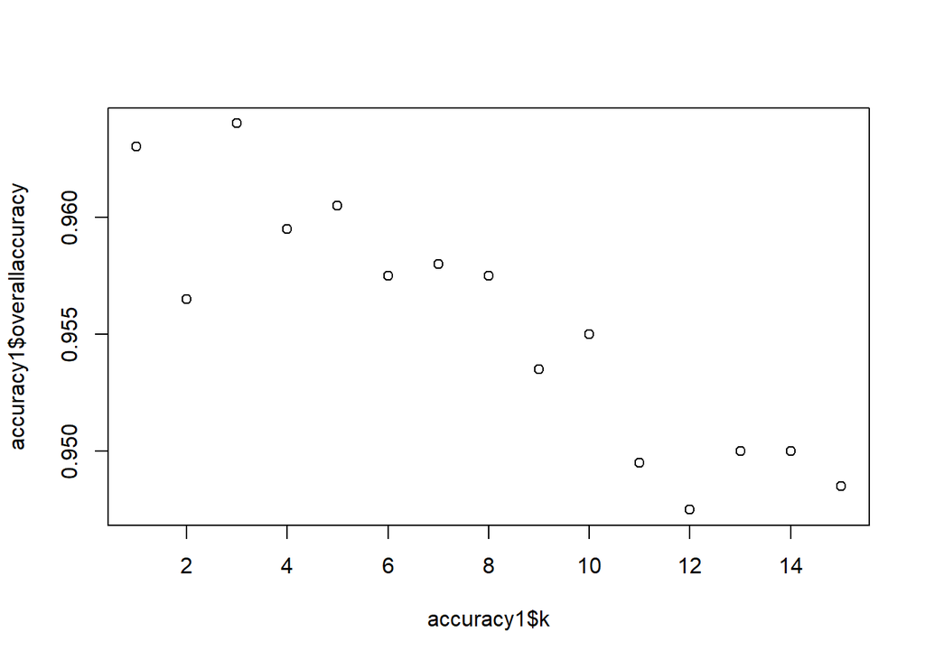

```r
plot(accuracy1$k,accuracy1$overallaccuracy)
```

3.Show the confusion matrix for the validation data that results from using the best k.

```r
# Creating the confusion matrix

pred <- class::knn(train = train.norm,
test = valid.norm,
cl = train$Personal.Loan, k=3)

confusionMatrix(pred,as.factor(valid$Personal.Loan))
```

```
## Confusion Matrix and Statistics
##
##           Reference
## Prediction    0    1
##          0 1786   63
##          1    9  142
##
##                Accuracy : 0.964
##                  95% CI : (0.9549, 0.9717)
##     No Information Rate : 0.8975
##     P-Value [Acc > NIR] : < 2.2e-16
##
##                   Kappa : 0.7785
##
##  Mcnemar's Test P-Value : 4.208e-10
##
##             Sensitivity : 0.9950
##             Specificity : 0.6927
##          Pos Pred Value : 0.9659
##          Neg Pred Value : 0.9404
##              Prevalence : 0.8975
##          Detection Rate : 0.8930
##    Detection Prevalence : 0.9245
##       Balanced Accuracy : 0.8438
##
##        'Positive' Class : 0
##
```

Now creating the 2nd new customer dataset

```r
customer2.df <- data.frame(
Age = 40,
Experience = 10,
Income = 84,
Family = 2,
CCAvg = 2,
Education.1 = 0,
Education.2 = 1,
Education.3 = 0,
Mortgage = 0,
Securities.Account = 0,
CD.Account = 0,
Online = 1,
CreditCard = 1)
#Normalizing the 2nd customer dataset
cust_norm2 <- predict(norm , customer2.df)
```

```r
set.seed(400)
Train_Index <- sample(row.names(the.info), .5*dim(the.info)[1])#create train index

#create validation index
Val_Index <- sample(setdiff(row.names(the.info),Train_Index),.3*dim(the.info)[1])
Test_Index =setdiff(row.names(the.info),union(Train_Index,Val_Index))#create test index
train.df <- the.info[Train_Index,]
cat("The size of the new training dataset is:", nrow(train.df))
```

```
## The size of the new training dataset is: 2500
```

```r
valid.df <- the.info[Val_Index, ]
cat("The size of the new validation dataset is:", nrow(valid.df))
```

```
## The size of the new validation dataset is: 1500
```

```r
test.df <- the.info[Test_Index, ]
cat("The size of the new test dataset is:", nrow(test.df))
```

```
## The size of the new test dataset is: 1000
```

# Data Normalizing

```r
norm.values <- preProcess(train.df[, -10], method=c("center", "scale"))
train.df.norm <- predict(norm.values, train.df[, -10])
valid.df.norm <- predict(norm.values, valid.df[, -10])
test.df.norm <- predict(norm.values, test.df[,-10])
```

# Performing kNN and creating confusion matrix on training, testing, validation data

```r
pred3 <- class::knn(train = train.df.norm,
test = test.df.norm,
cl = train.df$Personal.Loan, k=3)
confusionMatrix(pred3,as.factor(test.df$Personal.Loan))
```

```
## Confusion Matrix and Statistics
##
##           Reference
## Prediction   0   1
##          0 897  47
##          1   5  51
##
##                Accuracy : 0.948
##                  95% CI : (0.9324, 0.9609)
##     No Information Rate : 0.902
##     P-Value [Acc > NIR] : 7.644e-08
##
##                   Kappa : 0.6364
##
##  Mcnemar's Test P-Value : 1.303e-08
##
##             Sensitivity : 0.9945
##             Specificity : 0.5204
##          Pos Pred Value : 0.9502
##          Neg Pred Value : 0.9107
##              Prevalence : 0.9020
##          Detection Rate : 0.8970
##    Detection Prevalence : 0.9440
##       Balanced Accuracy : 0.7574
##
##        'Positive' Class : 0
##
```

```r
pred4 <- class::knn(train = train.df.norm,
test = valid.df.norm,
cl = train.df$Personal.Loan, k=3)
confusionMatrix(pred4,as.factor(valid.df$Personal.Loan))
```

```
## Confusion Matrix and Statistics
##
##           Reference
## Prediction    0    1
##          0 1363   50
##          1    3   84
##
##                Accuracy : 0.9647
##                  95% CI : (0.954, 0.9734)
##     No Information Rate : 0.9107
##     P-Value [Acc > NIR] : < 2.2e-16
##
##                   Kappa : 0.742
##
##  Mcnemar's Test P-Value : 2.64e-10
##
##             Sensitivity : 0.9978
##             Specificity : 0.6269
##          Pos Pred Value : 0.9646
##          Neg Pred Value : 0.9655
##              Prevalence : 0.9107
##          Detection Rate : 0.9087
##    Detection Prevalence : 0.9420
##       Balanced Accuracy : 0.8123
##
##        'Positive' Class : 0
##
```

```r
pred5 <- class::knn(train = train.df.norm,
test = train.df.norm,
cl = train.df$Personal.Loan, k=3)
confusionMatrix(pred5,as.factor(train.df$Personal.Loan))
```

```
## Confusion Matrix and Statistics
##
##           Reference
## Prediction    0    1
##          0 2246   51
##          1    6  197
##
##                Accuracy : 0.9772
##                  95% CI : (0.9706, 0.9827)
##     No Information Rate : 0.9008
##     P-Value [Acc > NIR] : < 2.2e-16
##
##                   Kappa : 0.8612
##
##  Mcnemar's Test P-Value : 5.611e-09
##
##             Sensitivity : 0.9973
##             Specificity : 0.7944
##          Pos Pred Value : 0.9778
##          Neg Pred Value : 0.9704
##              Prevalence : 0.9008
##          Detection Rate : 0.8984
##    Detection Prevalence : 0.9188
##       Balanced Accuracy : 0.8958
##
##        'Positive' Class : 0
##
```